# Project Report

Group 5: Ahmet Bugra Taksuk - Ahmet Tabakoglu - Yusuf Sina Ozturk

Last edited July 02, 2021

## Introduction

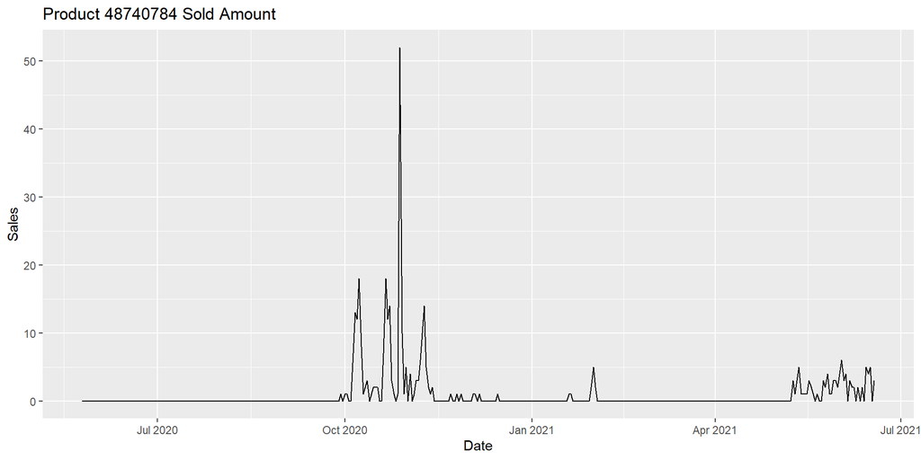

```r
pr1 <-read.csv("alldata_item1.csv")
pr1 <- mutate(pr1, event_date = mdy(event_date))

ggplot(data =  pr1 , aes(x=event_date, y= sold_count)) +
  geom_line(color = "black") +
  labs(title = "Product 48740784 Sold Amount",
       x = "Date",
       y= "Sales")
```

- As can be seen in the plot, the product 48740784 which is a winter coat has a very distinct and irregular pattern of sales data. Between the summer and the winter months, there is nearly no sales data. In the winter and summer months, there is sales data but it is hard to say that there is a seasonal or trend pattern. Thus, for these kind of products, it is reasonable to implement Linear Models as we have many variables to use in LM.

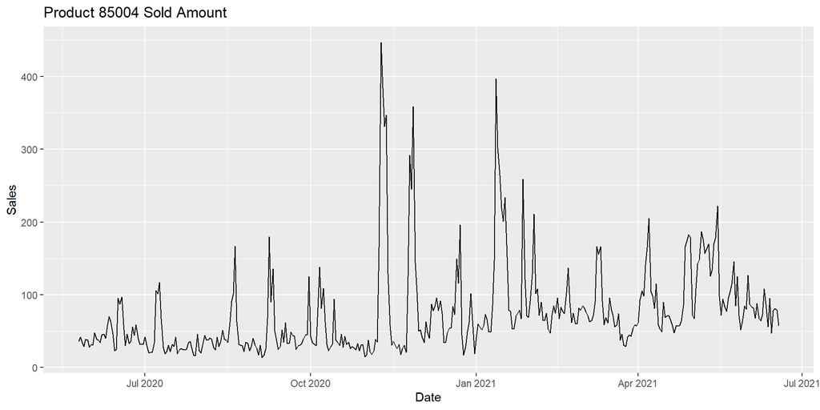

```r
pr7 <-read.csv("alldata_item7.csv")
pr7 <- mutate(pr7, event_date = ymd(event_date))

ggplot(data =  pr7 , aes(x=event_date, y= sold_count)) +
  geom_line(color = "black") +
  labs(title = "Product 85004 Sold Amount",
       x = "Date",
       y= "Sales")
```

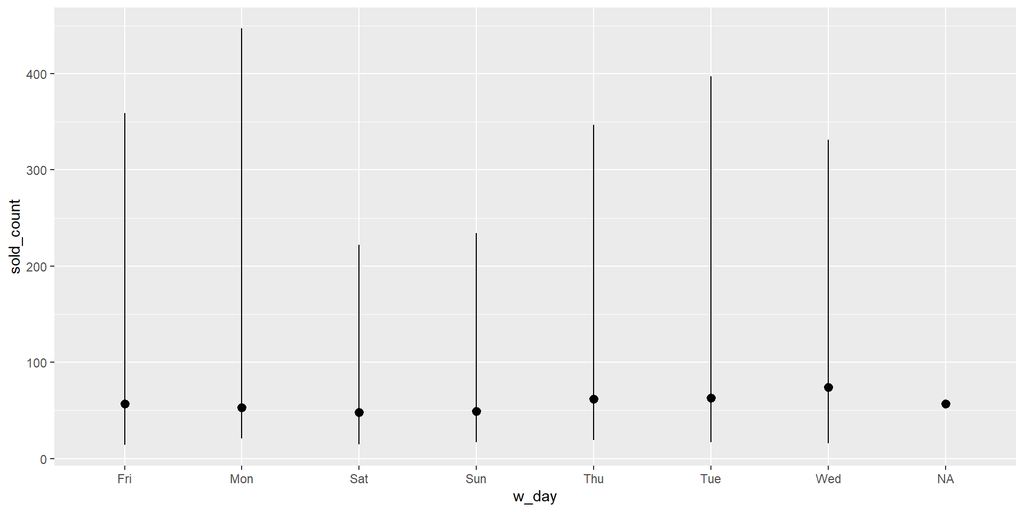

```r
ggplot(data = pr7) +
  stat_summary(
    mapping = aes(x = w_day, y = sold_count),
    fun.min = min,
    fun.max = max,
    fun = median
  )
```

- For the product 85004 which is a electronic toothbrush, as opposed to product above, we see a more regular pattern. From the sold amount versus week day, there is a seasonality term occurs every seven day. For these kind of models, we implemented the ARIMA or ARIMAX model because there were seasonal and trend terms and also data were continuous which makes MA or AR terms useful.

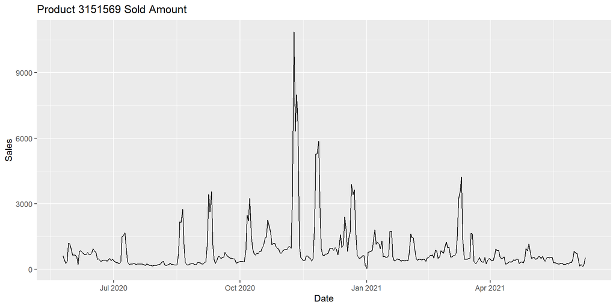

```r
pr4 <-read.csv("alldata_item4.csv")
pr4 <- mutate(pr4, event_date = ymd(event_date))
pr4 <- as.data.table(pr4)

ggplot(data =  pr4 , aes(x=event_date, y= sold_count)) +
  geom_line(color = "black") +
  labs(title = "Product 3151569 Sold Amount",
       x = "Date",
       y= "Sales")
```

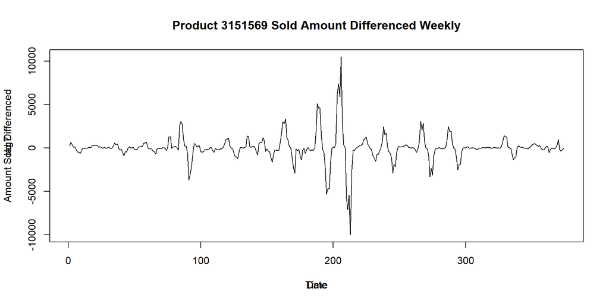

```r
lag7 = diff(pr4$sold_count,lag = 7)
lag7 <- ts(lag7)
plot(lag7)
title("Product 3151569 Sold Amount Differenced Weekly", xlab="Date", ylab="Amount Sold Differenced")
```

- For the product 31515569 which is a tight for women, we see again a continuous data that seems to have a seasonal pattern. To see it clearer, differenced with periods equal to seven is plotted. As we can see from the differenced series, there is a seasonal pattern that occurs every seven day. Nonetheless, there is still a seasonal term that is not covered by weekly seasonality. In this kind of situations, external regressors such as price information or basket count information is used to cover the variance by the model.

## Literature

- In this project, we are dealing with the task of forecasting each product’s next day sales amount. However, we are also given some variables that might be useful in predicting the sales amount. To begin with, “price” column refers to the price of the product that is displayed on the screen on a specific date. For some of the products like product 31515569, price information is used as regressor in the model. “Visit Count” column refers to the number of visits that the customer executed on that specific product bu this column is hard to use in the model because most of the row values are lost due to real life data losses. “Favored Count” refers to the number of customers who liked that product. “Basket Count” refers to the customers that put that product to their online shopping basket. “Category Sold” refers to the total sales of products that the product belongs to. “Category Brand SOld” and Category Visits" is similarly refer to the data related to Category.
- Beside from the variables, some products should be emphasized. Product 48740784 is a winter coat that is sold on winter months and summer month due to various campaigns. Product 73318567 and product 32737302 are bikinis that is sold mostly on summer months. Thus for these three products, there were no sales data at some points since Trendyol prefers not to put these product on the marketplace.
- After understanding of characteristic each product, there are some other affect coming from Trendyol. Such as every year, there is huge discount days such as Black Friday. Also, the e-commerce website has the mechanism that if you advertise your product in Trendyol, then users are see these products in their home pages more. Besides advertisement, websites are using search algorithms. Basically with machine learning algorithms, the Trendyol understand your behavior and according to your characteristic recommend products to you.

## Approach

### LM Model

We are using LM models in the products which do not have enough data for ARIMA or ARIMAX. Also some of the products does not have continuous sale at Trendyol such as Altinyildiz Coat (ID: 48740784). Because it is a winter coat, most of the meaningful data is in winter time. At this point, because we lose the continuity of time series, we have to build LM models for this kind of products.

```r
# reading data from local
pr1 = read.csv("alldata_item1.csv")
pr1 <- as.data.table(pr1)

# manipulation

pr1 <- pr1[,-c("X","w_day")] #subtract useless columns
pr1 <- mutate(pr1, event_date = mdy(event_date)) # converting event date into datetime object
pr1[, Month:=as.numeric(lubridate::month(event_date,label=F))] #adding month information as a numeric variable
pr1[, Day:=as.numeric(lubridate::wday(event_date,label=F))] #adding day information as a numeric variable

pr1 <- drop_na(pr1)
```

After dropping NA values, we have:

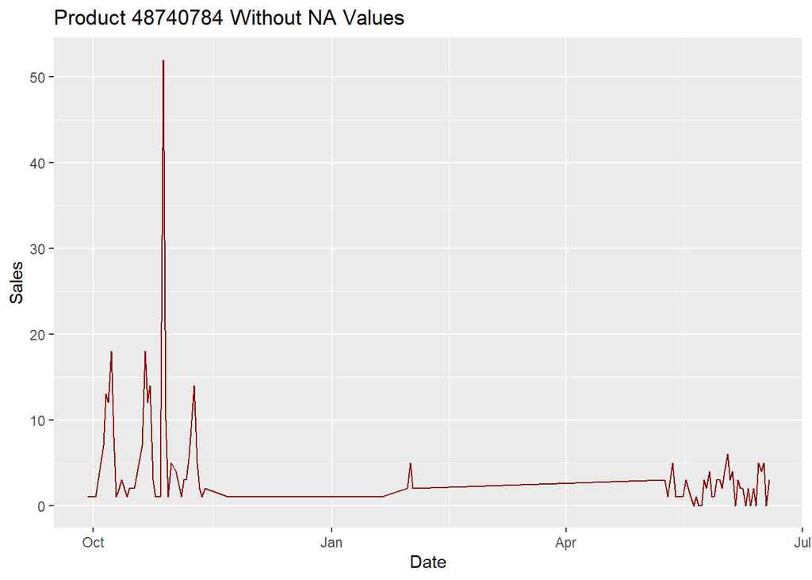

```r
ggplot(data =  pr1 , aes(x=event_date, y= sold_count)) +
  geom_line(color= "darkred") +
  labs(title = "Product 48740784 Without NA Values ",
       x = "Date",
       y= "Sales")
```

The approach that we are going to follow for LM model is putting all the attributes (excluding seasonal terms) into the model and choose the significant ones from summary of the model.

```r
lm1 <- lm(sold_count~. - Month - weeknumber - Day - event_date - product_content_id, data = pr1) # with all atributes excluding seasons
summary(lm1)
```

```
##
## Call:
## lm(formula = sold_count ~ . - Month - weeknumber - Day - event_date -
##     product_content_id, data = pr1)
##
## Residuals:
##     Min      1Q  Median      3Q     Max
## -6.5977 -1.2704 -0.2668  1.3565  7.9295
##
## Coefficients:
##                       Estimate Std. Error t value Pr(>|t|)
## (Intercept)          3.018e+00  1.629e+00   1.853   0.0677 .
## price               -6.418e-04  1.999e-03  -0.321   0.7491
## visit_count          3.232e-03  9.359e-03   0.345   0.7308
## favored_count       -7.455e-02  1.061e-01  -0.703   0.4843
## basket_count         2.005e-01  9.250e-03  21.679  < 2e-16 ***
## category_sold        1.573e-03  8.984e-04   1.751   0.0839 .
## category_brand_sold  1.260e-05  6.972e-06   1.808   0.0744 .
## category_visits     -4.651e-06  6.516e-06  -0.714   0.4775
## ty_visits           -1.920e-08  9.449e-09  -2.032   0.0455 *
## category_basket      1.143e-06  9.974e-07   1.146   0.2553
## category_favored    -6.687e-05  1.085e-05  -6.165  2.8e-08 ***
## ---
## Signif. codes:  0 '***' 0.001 '**' 0.01 '*' 0.05 '.' 0.1 ' ' 1
##
## Residual standard error: 2.426 on 79 degrees of freedom
## Multiple R-squared:  0.8735, Adjusted R-squared:  0.8575
## F-statistic: 54.57 on 10 and 79 DF,  p-value: < 2.2e-16
```

`visit_count` and `favored_count` should be correlated with basket count. Therefore, as a first step we subtract these attribute. Furthermore, `category_visits` should have correlation with `ty_visits` , we can subtract this one also.

```r
lm2 <- lm(sold_count~. - Month - weeknumber - Day - event_date - product_content_id -visit_count - favored_count - category_visits , data = pr1) # Second LM Model
summary(lm2)
```

```
##
## Call:
## lm(formula = sold_count ~ . - Month - weeknumber - Day - event_date -
##     product_content_id - visit_count - favored_count - category_visits,
##     data = pr1)
##
## Residuals:
##     Min      1Q  Median      3Q     Max
## -6.4685 -1.2579 -0.2759  1.1014  7.7672
##
## Coefficients:
##                       Estimate Std. Error t value Pr(>|t|)
## (Intercept)          3.362e+00  1.549e+00   2.170  0.03288 *
## price               -1.273e-03  1.878e-03  -0.678  0.49992
## basket_count         1.988e-01  9.051e-03  21.960  < 2e-16 ***
## category_sold        6.221e-04  4.723e-04   1.317  0.19147
## category_brand_sold  8.979e-06  6.228e-06   1.442  0.15321
## ty_visits           -2.290e-08  8.144e-09  -2.811  0.00617 **
## category_basket      1.162e-06  8.341e-07   1.393  0.16744
## category_favored    -5.900e-05  8.876e-06  -6.647 3.07e-09 ***
## ---
## Signif. codes:  0 '***' 0.001 '**' 0.01 '*' 0.05 '.' 0.1 ' ' 1
##
## Residual standard error: 2.41 on 82 degrees of freedom
## Multiple R-squared:  0.8705, Adjusted R-squared:  0.8594
## F-statistic: 78.74 on 7 and 82 DF,  p-value: < 2.2e-16
```

Because this pproduct’s `price` fluctuate in time, price do not affect the model. Also, `category_sold` and `category_brand_sold` does not have significant effect on the model.

```r
lm3 <- lm(sold_count~. - Month - weeknumber - Day - event_date - product_content_id -visit_count - favored_count - category_visits - category_sold - category_brand_sold - price , data = pr1) # Third LM Model
summary(lm3)
```

```
##
## Call:
## lm(formula = sold_count ~ . - Month - weeknumber - Day - event_date -
##     product_content_id - visit_count - favored_count - category_visits -
##     category_sold - category_brand_sold - price, data = pr1)
##
## Residuals:
##     Min      1Q  Median      3Q     Max
## -7.2157 -1.3708 -0.0363  1.3457  7.5605
##
## Coefficients:
##                    Estimate Std. Error t value Pr(>|t|)
## (Intercept)       2.448e+00  5.531e-01   4.427 2.83e-05 ***
## basket_count      1.953e-01  8.742e-03  22.339  < 2e-16 ***
## ty_visits        -1.666e-08  5.127e-09  -3.250  0.00165 **
## category_basket   1.360e-06  6.491e-07   2.095  0.03911 *
## category_favored -5.055e-05  6.980e-06  -7.242 1.85e-10 ***
## ---
## Signif. codes:  0 '***' 0.001 '**' 0.01 '*' 0.05 '.' 0.1 ' ' 1
##
## Residual standard error: 2.424 on 85 degrees of freedom
## Multiple R-squared:  0.8641, Adjusted R-squared:  0.8577
## F-statistic: 135.2 on 4 and 85 DF,  p-value: < 2.2e-16
```

Now, the model has significant regressors. We can add seasonal term into the model.

```r
lm4 <- lm(sold_count~. - event_date - product_content_id -visit_count - favored_count - category_visits - category_sold - category_brand_sold - price , data = pr1) # Fourth LM Model
summary(lm4)
```

```
##
## Call:
## lm(formula = sold_count ~ . - event_date - product_content_id -
##     visit_count - favored_count - category_visits - category_sold -
##     category_brand_sold - price, data = pr1)
##
## Residuals:
##    Min     1Q Median     3Q    Max
## -7.183 -1.407 -0.208  1.346  7.619
##
## Coefficients:
##                    Estimate Std. Error t value Pr(>|t|)
## (Intercept)       4.098e+00  1.816e+00   2.256  0.02670 *
## basket_count      1.957e-01  9.026e-03  21.684  < 2e-16 ***
## ty_visits        -2.126e-08  7.702e-09  -2.760  0.00713 **
## category_basket   9.836e-07  7.563e-07   1.300  0.19709
## category_favored -5.017e-05  7.150e-06  -7.017 5.94e-10 ***
## Month            -4.123e-01  9.100e-01  -0.453  0.65172
## weeknumber        6.047e-02  2.143e-01   0.282  0.77850
## Day              -2.235e-02  1.375e-01  -0.163  0.87126
## ---
## Signif. codes:  0 '***' 0.001 '**' 0.01 '*' 0.05 '.' 0.1 ' ' 1
##
## Residual standard error: 2.453 on 82 degrees of freedom
## Multiple R-squared:  0.8658, Adjusted R-squared:  0.8544
## F-statistic: 75.59 on 7 and 82 DF,  p-value: < 2.2e-16
```

After adding seasons, `category_basket` lost its significance. And because `weeknumber` and `Month` can be correlated with each other, `weeknumber` dropped.

```r
lm5 <- lm(sold_count~. - event_date - product_content_id -visit_count - favored_count - category_visits - category_sold - category_brand_sold - price - category_basket - weeknumber , data = pr1) # Fifth LM Model
summary(lm5)
```

```
##
## Call:
## lm(formula = sold_count ~ . - event_date - product_content_id -
##     visit_count - favored_count - category_visits - category_sold -
##     category_brand_sold - price - category_basket - weeknumber,
##     data = pr1)
##
## Residuals:
##     Min      1Q  Median      3Q     Max
## -7.4545 -1.4017 -0.1239  1.3464  7.5750
##
## Coefficients:
##                    Estimate Std. Error t value Pr(>|t|)
## (Intercept)       5.047e+00  1.666e+00   3.030  0.00325 **
## basket_count      1.958e-01  8.906e-03  21.980  < 2e-16 ***
## ty_visits        -2.293e-08  7.383e-09  -3.107  0.00258 **
## category_favored -4.835e-05  6.955e-06  -6.951 7.25e-10 ***
## Month            -2.677e-01  1.458e-01  -1.836  0.06988 .
## Day              -1.809e-02  1.363e-01  -0.133  0.89476
## ---
## Signif. codes:  0 '***' 0.001 '**' 0.01 '*' 0.05 '.' 0.1 ' ' 1
##
## Residual standard error: 2.452 on 84 degrees of freedom
## Multiple R-squared:  0.8627, Adjusted R-squared:  0.8545
## F-statistic: 105.5 on 5 and 84 DF,  p-value: < 2.2e-16
```

`Month` gain, a little significance. `ty_visits` and `Day` should have correlation with each other. Because `ty_visits` has huge numbers, `Day` can be affect the model better. Therefore, we can try to subtract `ty_visits`

```r
lm6 <- lm(sold_count~. - event_date - product_content_id -visit_count - favored_count - category_visits - category_sold - category_brand_sold - price - category_basket - weeknumber - ty_visits , data = pr1) # Sixth LM Model
summary(lm6)
```

```
##
## Call:
## lm(formula = sold_count ~ . - event_date - product_content_id -
##     visit_count - favored_count - category_visits - category_sold -
##     category_brand_sold - price - category_basket - weeknumber -
##     ty_visits, data = pr1)
##
## Residuals:
##    Min     1Q Median     3Q    Max
## -8.483 -1.393 -0.150  1.245  7.985
##
## Coefficients:
##                    Estimate Std. Error t value Pr(>|t|)
## (Intercept)       6.161e-01  9.026e-01   0.683    0.497
## basket_count      1.952e-01  9.346e-03  20.885  < 2e-16 ***
## category_favored -4.117e-05  6.886e-06  -5.979 5.13e-08 ***
## Month             7.128e-02  1.015e-01   0.702    0.484
## Day               3.063e-02  1.422e-01   0.215    0.830
## ---
## Signif. codes:  0 '***' 0.001 '**' 0.01 '*' 0.05 '.' 0.1 ' ' 1
##
## Residual standard error: 2.574 on 85 degrees of freedom
## Multiple R-squared:  0.8469, Adjusted R-squared:  0.8397
## F-statistic: 117.5 on 4 and 85 DF,  p-value: < 2.2e-16
```

Both seasonal term do not have significance in the model. We can subtract intercept to get better R-squared value:

```r
lm7 <- lm(sold_count~. - event_date - product_content_id -visit_count - favored_count - category_visits - category_sold - category_brand_sold - price - category_basket - weeknumber - ty_visits - 1 , data = pr1) # Seventh LM Model
summary(lm7)
```

```
##
## Call:
## lm(formula = sold_count ~ . - event_date - product_content_id -
##     visit_count - favored_count - category_visits - category_sold -
##     category_brand_sold - price - category_basket - weeknumber -
##     ty_visits - 1, data = pr1)
##
## Residuals:
##     Min      1Q  Median      3Q     Max
## -8.4492 -1.3064 -0.0585  1.3093  7.8852
##
## Coefficients:
##                    Estimate Std. Error t value Pr(>|t|)
## basket_count      1.952e-01  9.317e-03  20.953  < 2e-16 ***
## category_favored -4.098e-05  6.859e-06  -5.974 5.07e-08 ***
## Month             1.149e-01  7.863e-02   1.461    0.148
## Day               8.419e-02  1.182e-01   0.712    0.478
## ---
## Signif. codes:  0 '***' 0.001 '**' 0.01 '*' 0.05 '.' 0.1 ' ' 1
##
## Residual standard error: 2.566 on 86 degrees of freedom
## Multiple R-squared:  0.8883, Adjusted R-squared:  0.8831
## F-statistic:   171 on 4 and 86 DF,  p-value: < 2.2e-16
```

Seasonal terms does not look like have significance in the model, so we can subtract them to see whether R-squared value increased or not.

```r
lm8 <- lm(sold_count~. - event_date - product_content_id -visit_count - favored_count - category_visits - category_sold - category_brand_sold - price - category_basket - weeknumber - ty_visits - 1 - Month, data = pr1) # Seventh LM Model
summary(lm8)
```

```
##
## Call:
## lm(formula = sold_count ~ . - event_date - product_content_id -
##     visit_count - favored_count - category_visits - category_sold -
##     category_brand_sold - price - category_basket - weeknumber -
##     ty_visits - 1 - Month, data = pr1)
##
## Residuals:
##     Min      1Q  Median      3Q     Max
## -8.7809 -1.1948  0.1098  1.4705  7.9448
##
## Coefficients:
##                    Estimate Std. Error t value Pr(>|t|)
## basket_count      1.985e-01  9.095e-03  21.830  < 2e-16 ***
## category_favored -3.689e-05  6.303e-06  -5.853 8.35e-08 ***
## Day               2.172e-01  7.579e-02   2.866  0.00521 **
## ---
## Signif. codes:  0 '***' 0.001 '**' 0.01 '*' 0.05 '.' 0.1 ' ' 1
##
## Residual standard error: 2.582 on 87 degrees of freedom
## Multiple R-squared:  0.8856, Adjusted R-squared:  0.8816
## F-statistic: 224.4 on 3 and 87 DF,  p-value: < 2.2e-16
```

```r
lm9 <- lm(sold_count~. - event_date - product_content_id -visit_count - favored_count - category_visits - category_sold - category_brand_sold - price - category_basket - weeknumber - ty_visits - 1 - Day, data = pr1) # Seventh LM Model
summary(lm9)
```

```
##
## Call:
## lm(formula = sold_count ~ . - event_date - product_content_id -
##     visit_count - favored_count - category_visits - category_sold -
##     category_brand_sold - price - category_basket - weeknumber -
##     ty_visits - 1 - Day, data = pr1)
##
## Residuals:
##     Min      1Q  Median      3Q     Max
## -8.6768 -1.3247 -0.1466  1.5030  7.9251
##
## Coefficients:
##                    Estimate Std. Error t value Pr(>|t|)
## basket_count      1.947e-01  9.262e-03  21.021  < 2e-16 ***
## category_favored -4.135e-05  6.820e-06  -6.063 3.35e-08 ***
## Month             1.581e-01  4.996e-02   3.163  0.00215 **
## ---
## Signif. codes:  0 '***' 0.001 '**' 0.01 '*' 0.05 '.' 0.1 ' ' 1
##
## Residual standard error: 2.558 on 87 degrees of freedom
## Multiple R-squared:  0.8877, Adjusted R-squared:  0.8838
## F-statistic: 229.2 on 3 and 87 DF,  p-value: < 2.2e-16
```

While we subtract them from the model, there is no increase in the model. Because we take them as numeric, seems like they do no effect on the model. Therefore, we are continue with `Day` and `Month` variable.

Final LM model is:

```r
lmfinal <- lm(sold_count~. - event_date - product_content_id -visit_count - favored_count - category_visits - category_sold - category_brand_sold - price - category_basket - weeknumber - ty_visits - 1 , data = pr1) # Final LM Model
summary(lmfinal)
```

```
##
## Call:
## lm(formula = sold_count ~ . - event_date - product_content_id -
##     visit_count - favored_count - category_visits - category_sold -
##     category_brand_sold - price - category_basket - weeknumber -
##     ty_visits - 1, data = pr1)
##
## Residuals:
##     Min      1Q  Median      3Q     Max
## -8.4492 -1.3064 -0.0585  1.3093  7.8852
##
## Coefficients:
##                    Estimate Std. Error t value Pr(>|t|)
## basket_count      1.952e-01  9.317e-03  20.953  < 2e-16 ***
## category_favored -4.098e-05  6.859e-06  -5.974 5.07e-08 ***
## Month             1.149e-01  7.863e-02   1.461    0.148
## Day               8.419e-02  1.182e-01   0.712    0.478
## ---
## Signif. codes:  0 '***' 0.001 '**' 0.01 '*' 0.05 '.' 0.1 ' ' 1
##
## Residual standard error: 2.566 on 86 degrees of freedom
## Multiple R-squared:  0.8883, Adjusted R-squared:  0.8831
## F-statistic:   171 on 4 and 86 DF,  p-value: < 2.2e-16
```

To do forecast with these regressors, seasonal terms (`Day` and `Month`) naturally given. For `basket_count` and `category_favored`, we follow several approaches. At the beginning of the project; if there is peaks in the last days, we took 7 or 5th order moving average of the variable. If the variable seems like keep it on the same level, then we only take 3rd order moving average. Later, we try to built LM models with only seasonal terms (Day, weeknumber and Month) for the regressors in the model. If that models have R-squared value higher than 0.70 (our threshold value), we predict with that model for the next day.

### ARIMA Model

For this approach, the model construction steps for product 6676673 will be shown as an example. First, the sales data is converted to time series data on weekly and monthly levels. Then, the random components for each level of decomposition is investigated by plotting ACF and PACF graphs and applying KPSS test.

First, decomposition for monthly level is applied.

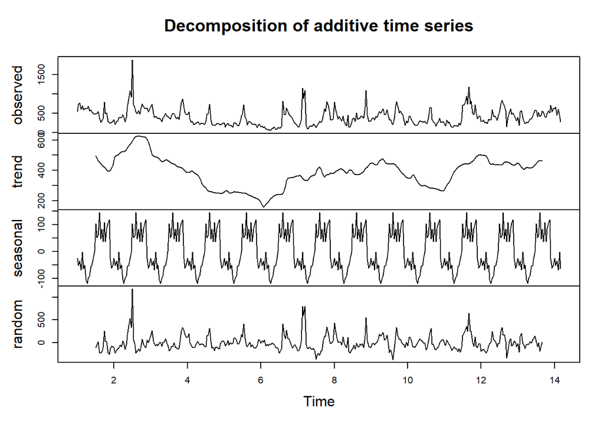

```r
pr5 <- read_excel("item5.xlsx")
monthlytspr5 <- ts(pr5$sold_count, freq = 30, start = c(1,1))
decmonthlypr5 <- decompose(monthlytspr5, type = "additive")
plot(decmonthlypr5)
```

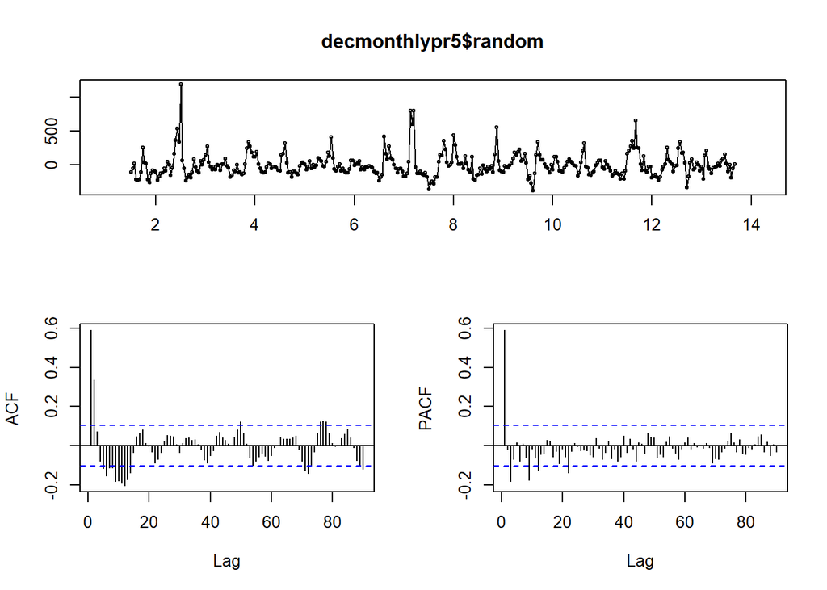

```r
tsdisplay(decmonthlypr5$random)
```

```r
kpss.test(decmonthlypr5$random)
```

```
##
##  KPSS Test for Level Stationarity
##
## data:  decmonthlypr5$random
## KPSS Level = 0.019189, Truncation lag parameter = 5, p-value = 0.1
```

Then, decomposition for weekly level is applied.

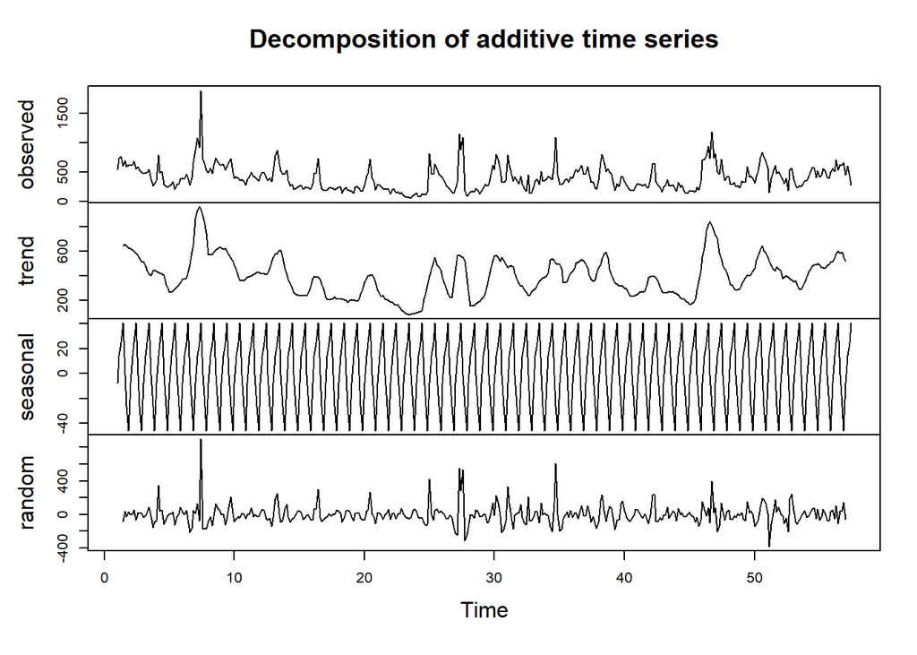

```r
weeklytspr5 <- ts(pr5$sold_count, freq = 7, start = c(1,1))
decweeklypr5 <- decompose(weeklytspr5, type = "additive")
plot(decweeklypr5)
```

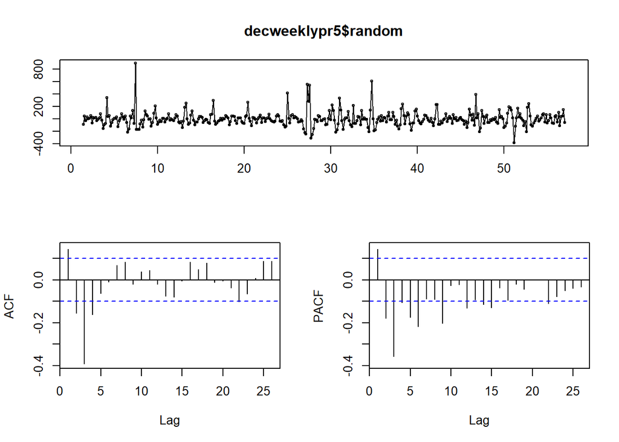

```r
tsdisplay(decweeklypr5$random)
```

```r
kpss.test(decweeklypr5$random)
```

```
##
##  KPSS Test for Level Stationarity
##
## data:  decweeklypr5$random
## KPSS Level = 0.0088767, Truncation lag parameter = 5, p-value = 0.1
```

In the ACF and PACF plots of the random component of weekly time series data, an extremely high autocorrelation is detected at the third lag. Therefore, it is decided to construct a new time series data with a frequency of 3.

Decomposition for three-daily time series data is applied.

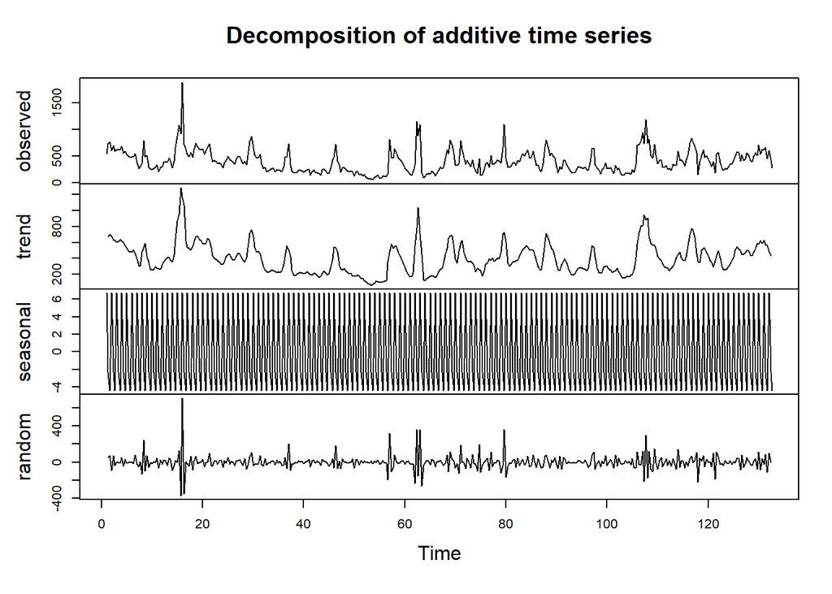

```r
threetspr5 <- ts(pr5$sold_count, freq = 3, start = c(1,1))
decthreepr5 <- decompose(threetspr5, type = "additive")
plot(decthreepr5)
```

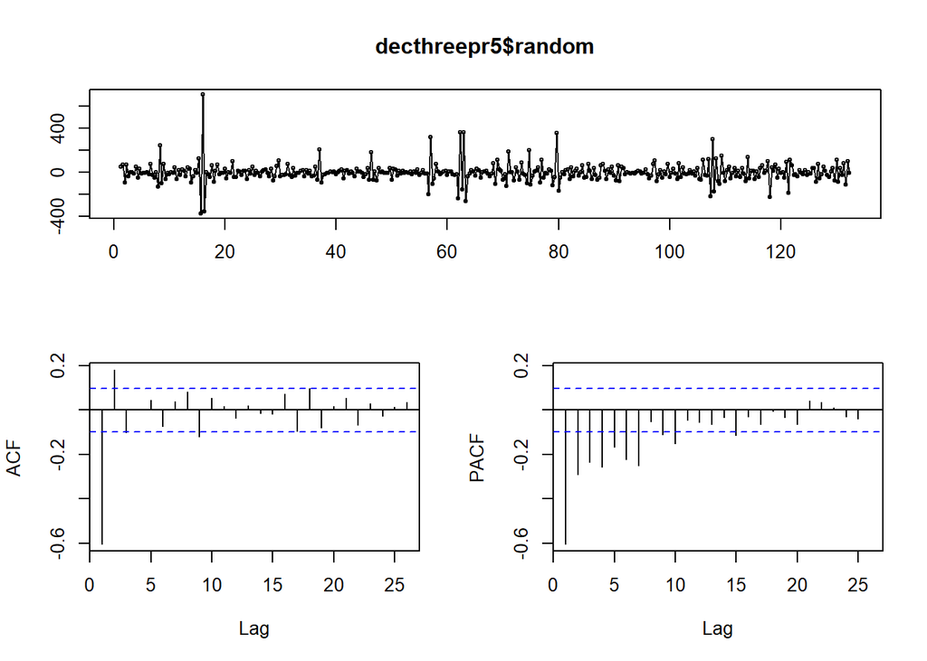

```r
tsdisplay(decthreepr5$random)
```

```r
kpss.test(decthreepr5$random)
```

```
##
##  KPSS Test for Level Stationarity
##
## data:  decthreepr5$random
## KPSS Level = 0.0097512, Truncation lag parameter = 5, p-value = 0.1
```

To find a suitable ARIMA model, using the ACF and PACF plots of the random term, ARIMA(0,0,2) is chosen as an initial model and using the neighborhood search, this model is improved.

```r
randompr5 <- decthreepr5$random

pr5arima <- arima(randompr5, order = c(0,0,2))
pr5arima
```

```
##
## Call:
## arima(x = randompr5, order = c(0, 0, 2))
##
## Coefficients:
##           ma1     ma2  intercept
##       -1.2438  0.2439    -0.0014
## s.e.   0.0560  0.0557     0.0177
##
## sigma^2 estimated as 2767:  log likelihood = -2123.69,  aic = 4255.38
```

```r
pr5ar1 <- arima(randompr5, order=c(0,0,1))
pr5ar1
```

```
##
## Call:
## arima(x = randompr5, order = c(0, 0, 1))
##
## Coefficients:
##           ma1  intercept
##       -0.9999    -0.0001
## s.e.   0.0064     0.0239
##
## sigma^2 estimated as 2917:  log likelihood = -2133.78,  aic = 4273.55
```

```r
pr5ar2 <- arima(randompr5, order=c(0,0,3))
pr5ar2
```

```
##
## Call:
## arima(x = randompr5, order = c(0, 0, 3))
##
## Coefficients:
##           ma1     ma2     ma3  intercept
##       -1.2713  0.1808  0.0905    -0.0021
## s.e.   0.0565  0.0709  0.0651     0.0150
##
## sigma^2 estimated as 2751:  log likelihood = -2122.73,  aic = 4255.45
```

```r
pr5ar3 <- arima(randompr5, order=c(1,0,2))
pr5ar3 #lowest AIC
```

```
##
## Call:
## arima(x = randompr5, order = c(1, 0, 2))
##
## Coefficients:
##          ar1      ma1     ma2  intercept
##       0.7172  -1.9893  0.9893    -0.0038
## s.e.  0.0208      NaN     NaN     0.0027
##
## sigma^2 estimated as 2485:  log likelihood = -2106.19,  aic = 4222.38
```

```r
pr5model <- pr5ar3
```

After the neighborhood search, ARIMA(1,0,2) model is selected.

To test the proficiency of the constructed ARIMA model, the graph for fitted model vs actual sales data is plotted.

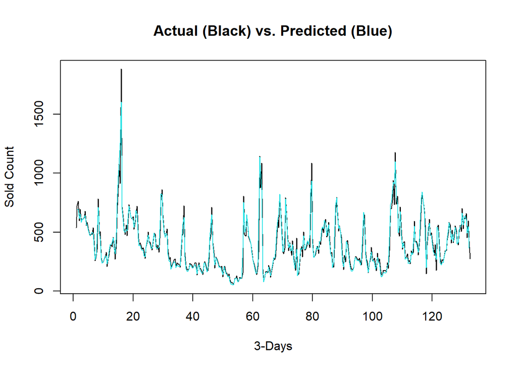

```
## integer(0)
```

```r
model_fitted_pr5 <- randompr5 - residuals(pr5model)
model_fitted_transformed_pr5 <- model_fitted_pr5+decthreepr5$trend+decthreepr5$seasonal
plot(threetspr5, xlab = "3-Days", ylab = "Sold Count",main="Actual (Black) vs. Predicted (Blue)")+points(model_fitted_transformed_pr5, type = "l", col = 5, lty = 1)
```

### ARIMAX Model

For the ARIMAX model approach, to simply examplify the steps of this method, the previous ARIMA model for product 6676673 can be used. To derive an ARIMAX model from the already constructed ARIMA(1,0,2) model, first the possible external regressors should be evaluated whether they are suitable to use.

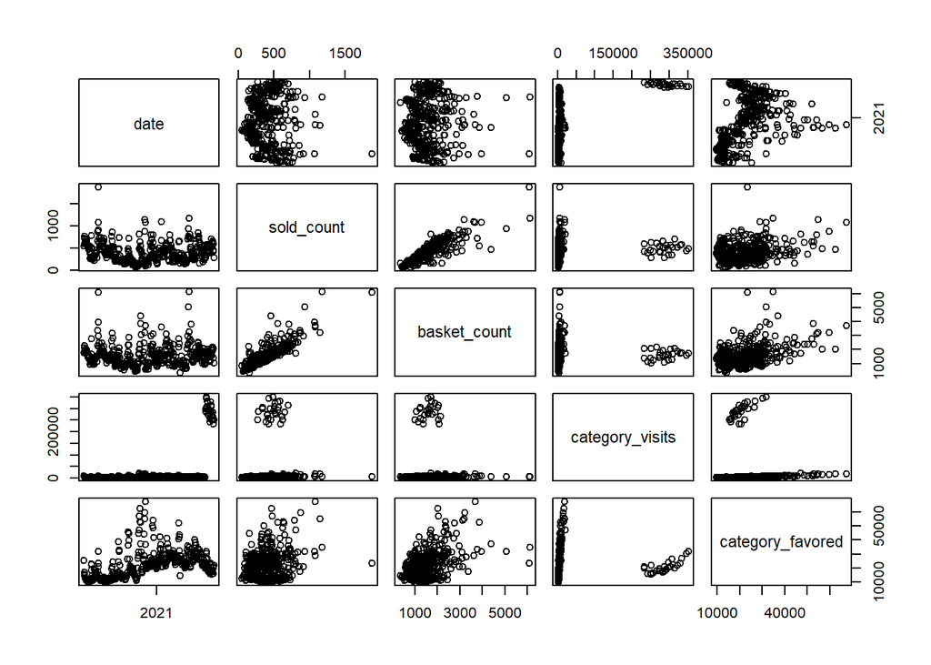

```r
pr5data <- data.frame(date = pr5$event_date, sold_count = pr5$sold_count, basket_count = pr5$basket_count, category_visits = pr5$category_visits, category_favored = pr5$category_favored)
pairs(pr5data)
```

According to the pairplot, “basket count” and “category favored” columns are chosen to be added to the model as external regressors.

Adding the chosen external regressors to the model:

```r
regressorspr5 <- data.frame(pr5$basket_count, pr5$category_favored)
arimaxpr5 <- arima(randompr5, order = c(1,0,2), xreg = regressorspr5)
arimaxpr5
```

```
##
## Call:
## arima(x = randompr5, order = c(1, 0, 2), xreg = regressorspr5)
##
## Coefficients:
##          ar1      ma1     ma2  intercept  pr5.basket_count
##       0.6705  -1.9840  0.9859    -0.2760             2e-04
## s.e.  0.0438   0.0197  0.0198     0.1378             1e-04
##       pr5.category_favored
##                          0
## s.e.                     0
##
## sigma^2 estimated as 2459:  log likelihood = -2101.95,  aic = 4217.91
```

Looking at the significance values of the regressors, it can be said that the second regressor “category favored” has lost its significance. Therefore, the model can be rebuilt using the first regressor only.

```r
arimaxpr5 <- arima(randompr5, order = c(1,0,2), xreg = pr5data$basket_count)
arimaxpr5
```

```
##
## Call:
## arima(x = randompr5, order = c(1, 0, 2), xreg = pr5data$basket_count)
##
## Coefficients:
##          ar1      ma1     ma2  intercept  pr5data$basket_count
##       0.6716  -1.9874  0.9891    -0.2701                 2e-04
## s.e.  0.0402   0.0153  0.0168     0.0554                   NaN
##
## sigma^2 estimated as 2454:  log likelihood = -2101.87,  aic = 4215.74
```

To test the proficiency of the constructed ARIMAX model, the graph for fitted model vs actual sales data is plotted.

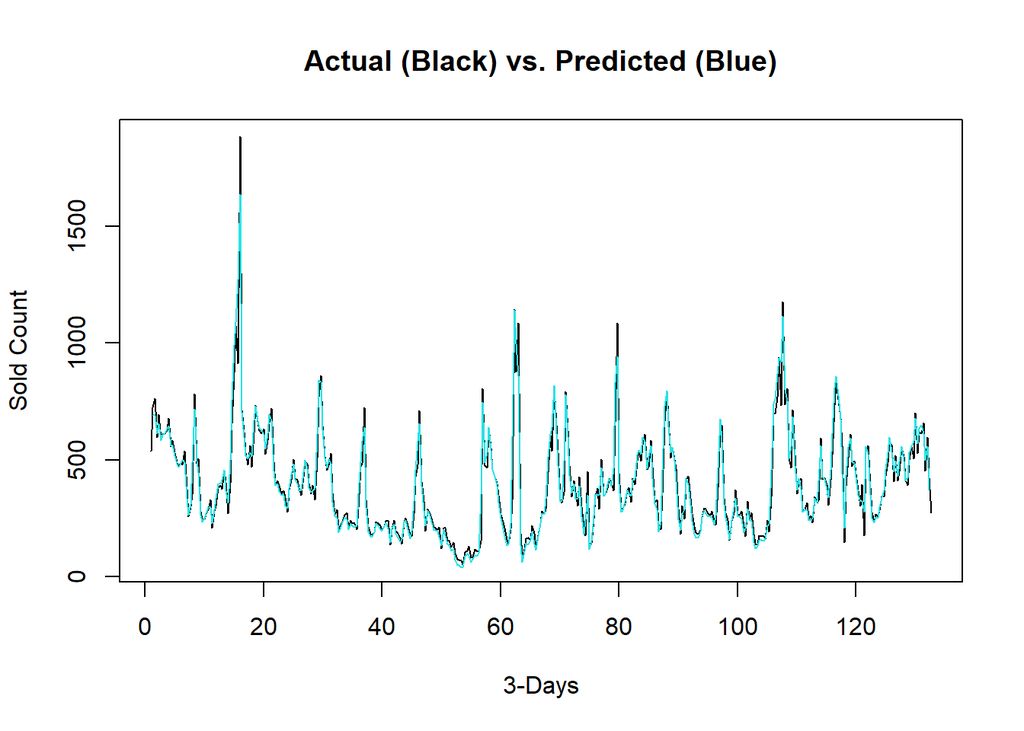

```
## integer(0)
```

```r
arimaxmodel_fitted_pr5 <- randompr5 - residuals(arimaxpr5)
arimaxmodel_fitted_transformed_pr5 <- arimaxmodel_fitted_pr5+decthreepr5$trend+decthreepr5$seasonal
plot(threetspr5, xlab = "3-Days", ylab = "Sold Count",main="Actual (Black) vs. Predicted (Blue)")+points(arimaxmodel_fitted_transformed_pr5, type = "l", col = 5, lty = 1)
```

## Results

In this part, the prediction results for the period between 12th of June, 2021 and 26th of June, 2021 for each product will be summarized. Every prediction was made by using the data until 2 days before the prediction day. That is, for example, in 14th of June, the predictions were made for 15th of June using the data until 13th of June. Prediction results for the 9 products are shown below:

```r
predictions <- read_excel("pred.xlsx")
predictions
```

```
## # A tibble: 15 x 10
##    Date                `#48740784` `#73318567` `#32737302` `#31515569`
##    <dttm>                    <dbl>       <dbl>       <dbl>       <dbl>
##  1 2021-06-12 00:00:00           0          51          44         557
##  2 2021-06-13 00:00:00           2          44          44         337
##  3 2021-06-14 00:00:00           2          39          41         204
##  4 2021-06-15 00:00:00           2          39          67         419
##  5 2021-06-16 00:00:00           4         101          90         413
##  6 2021-06-17 00:00:00           5          65          82         340
##  7 2021-06-18 00:00:00           4          69          82         389
##  8 2021-06-19 00:00:00           2          77         196         280
##  9 2021-06-20 00:00:00           1          71          90         340
## 10 2021-06-21 00:00:00           0          63          61         269
## 11 2021-06-22 00:00:00           0          43          75         304
## 12 2021-06-23 00:00:00           1          41          70         241
## 13 2021-06-24 00:00:00           1          34          65         198
## 14 2021-06-25 00:00:00           1          38          77         218
## 15 2021-06-26 00:00:00           1          40          57         271
## # ... with 5 more variables: #6676673 <dbl>, #7061886 <dbl>, #85004 <dbl>,
## #   #4066298 <dbl>, #32939029 <dbl>
```

Since the predictions were made daily, and there was time to work on the models, the predictions tended to be more accurate by the time. However, since there is daily effects, such as an unexpected discount on a product, the predictions were sometimes not good enough to ensure the consistency in the models.

## Conclusion and Future Work

- We follow for each product different approach according to its characteristic and the data volume. With enough data, we try to build ARIMA or ARIMAX models with weekly decomposition. For small data sets, we have to construct LM models with regressors. To develop further, for the external regressors and significant attributes in LM models, we try to predict these regressors also. With building different LM models for each regressors, we also want to have more accurate predictions.
- To get better results in prediction of sales, we can add other regressors. Such as, discount days in Trendyol. Every year in specific days, there is huge discounts for a limited time. If we add that information into models, we can detect outliers better.
- Also, we can check whether seller of the product buy advertisement for that product. Because if a seller advertise for its product, then customers see that product in their screens and the chance of buying that product increase.
- Furtmore, we predict seasonal clothes such as winter coat and bikinis. If we add the weather conditions of Istanbul, then morelikely we can built our model better. Because even we are in summer days right now, bikini sells should affect from weather conditions. In warmer days, people think more to go to the beach and holidays.

### CODES

You can find below for each product the code scripts:

Product ID: 31515569

Product ID: 6676673

Product ID: 7061886

Product ID: 85004

Product ID: 4066298

Product ID: 32939029

Product ID: 48740784, 73318567, 32737302